# Git and version control

Author

Murray Logan

Published

January 19, 2024

**Other useful tutorials or resources**

- https://git-scm.com/book/en/v2
- https://www.atlassian.com/git/tutorials
- https://marklodato.github.io/visual-git-guide/index-en.html
- https://git-scm.com/docs/gittutorial
- https://marklodato.github.io/visual-git-guide/index-en.html
- https://try.github.io/levels/1/challenges/1
- https://onlywei.github.io/explain-git-with-d3/
- http://git-school.github.io/visualizing-git/
- https://github.com/sensorflo/git-draw

This tutorial will take a modular approach. The first section will provide an overview of the basic concepts of git. The second section will provide a quick overview of basic usage and the third and final section will cover intermediate level usage. In an attempt to ease understanding, the tutorial will blend together git commands and output, schematic diagrams and commentary in an attempt to ease understanding.

The following table surves as both a key and overview of the most common actions and git ‘verbs’.

| Initialize git | `git init` | Establish a git repository (within the current path if no path provided) |
| --- | --- | --- |
| Staging | `git add <file>` where `file` is one or more files to stage | Staging is indicating which files and their states are to be included in the next commit. |
| Committing | `git commit -m "<Commit message>"` where `<Commit message>` is a message to accompany the commit | Commiting generates a ‘snapshot’ of the file system. |
| Checkout | `git checkout "<commit>"` where `<commit>` is a reference to a commit to be reviewed | Explore the state associated with a specific commit |
| Reset | `git reset --hard "<commit>"` where `<commit>` is a reference to a commit | Return to a previous state, effectively erasing subsequent commits.. |
| Revert | `git revert "<commit>"` where `<commit>` is a reference to a commit that should be nullified (inverted) | Generate a new commit that reverses the changes introduced by a commit thereby effectively rolling back to a previous state (the one prior to the nominated commit) whilst still maintaining full commit… |
| Branching | `git branch <name>` `git checkout <name>` where `<name>` is a reference to a branch name (e.g. ‘Feature’) | Take edits in the project in a new direction to allow for modifications that will not affect the main (master) branch. |
| Merging | `git checkout master` `git branch <name>` where `<name>` is a reference to a branch name (e.g. ‘Feature’) that is to be merged back into `master`. | Incorporate changes in a branch into another branch (typically `master`). |
| Rebasing | `git rebase -i HEAD~<number>` where `<number>` is the number of previous commits to squash together with head. | Combine multiple commits together into a single larger commit. |
| Pulling | `git pull -u <remote> <branch>` where `<remote>` is the name of the remote (typically `origin`) and `<branch>` is the branch to sync with remote (typically `master`). | Pull changes from a branch of a remote repository. |
| Pushing | `git push -u <remote> <branch>` where `<remote>` is the name of the remote (typically `origin`) and `<branch>` is the branch to sync with remote (typically `master`). | Push changes up to a branch of a remote repository. |

# 1 Context

Git is a distributed versioning system. This means that the complete contents and history of a repository (in simplistic terms a repository is a collection of files and associated metadata) can be completely duplicated across multiple locations.

No doubt you have previously been working on a file (could be a document, spreadsheet, script or any other type of file) and got to a point where you have thought that you are starting to make edits that substantially change the file and therefore have considered saving the new file with a new name that indicates that it is a new version.

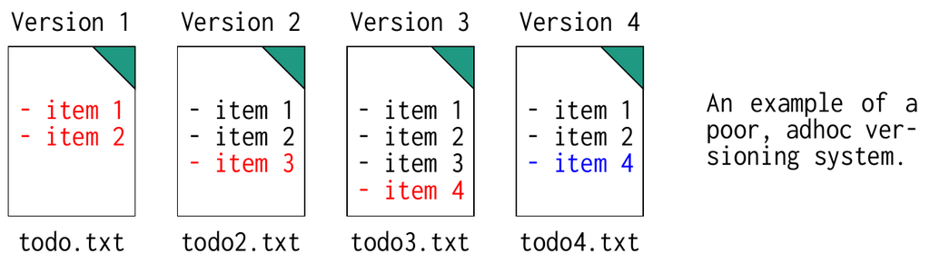

In the above diagram, new content is indicated in red and modifications in blue.

Whist this approach is ok, it is fairly limited and unsophisticated approach to versioning (keeping multiple versions of a file). Firstly, if you edit this file over many sessions and each time save with a different name, it becomes very difficult to either keep tract of what changes are associated with each version of the file, or the order in which the changes were made. This is massively compounded if a project comprises multiple files or has multiple authors.

Instead, imagine a system in which you could take a snapshot of state of your files and also provide a description outlining what changes you have made. Now imagine that the system was able to store and keep track of a succession of such versions in such a way that allows you to roll back to any previous versions of the files and exchange the entire history of changes with others collaborators - that is the purpose of git.

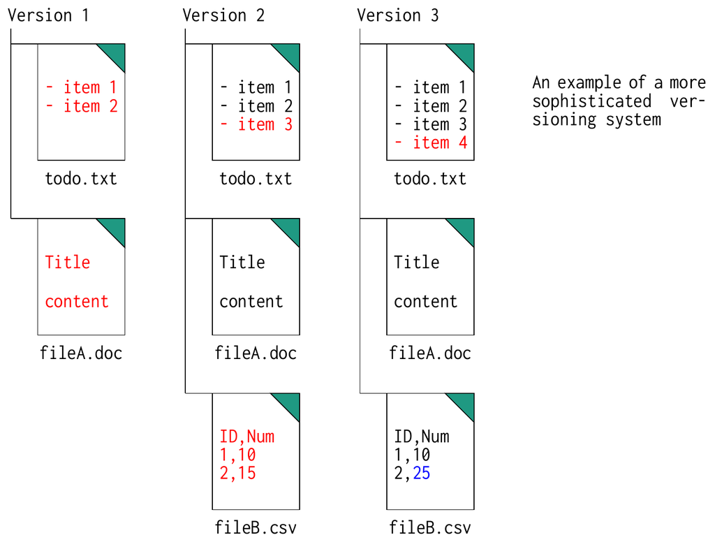

In the above diagram (which I must point out is **not actually how git works**), you can see that we are keeping track of multiple documents and potentially multiple changes within each document. What constitutes a version (as in how many changes and to what files) is completely arbitrary. Each individual edit can define a separate version.

One of the issues with the above system is that there is a lot of redundancy. With each new version an addition copy of the project’s entire filesystem (all its files) must be stored. In the above case, Version 2 and 3 both contain identical copies of `fileA.doc`. Is there a way of reducing the required size of the snapshots by only keeping copies of those that have actually changed? **this is what git achieves**. Git versions (or snapshots known as *commits*) store files that have changed since the previous and files that have not changed are only represented by links to instances of these files within previous snapshots.

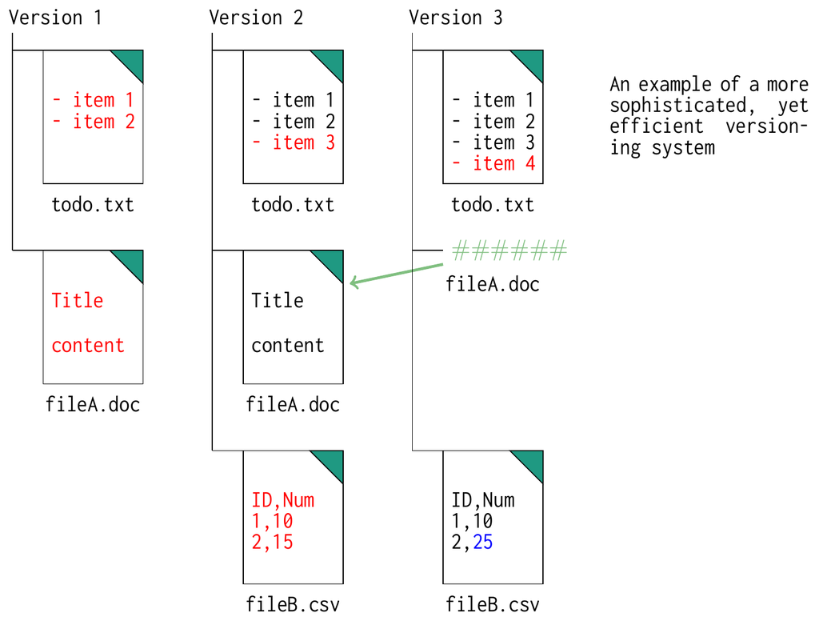

Now consider the following:

- You might have noticed that a new version can comprise multiple changes across multiple files. However, what if we have made numerous changes to numerous files over the course of an editing session (perhaps simultaneously addressing multiple different editing suggestions at a time), yet we did not want to lump all of these changes together into a single save point (snapshot). For example, the multiple changes might constitute addressing three independent issues, so although all edits were made simultaneously, we wish to record and describe the changes in three separate snapshots.
- What if this project had multiple contributors some of whom are working on new components of the project and some whom are working simultaneously on the same set of files? How can the system ensure that all contributors are in sync with each other and that new components are only introduced to the project proper once they are stable and agreed upon?
- What if there are files present within our project that we do not wish to keep track of. These files could be log files, compilation intermediates etc.
- Given that projects can comprise many files (some of which can be large), is it possible to store compressed files so as to reduce the storage and bandwidth burden?

# 2 Overview of git

The above discussion provides context for understanding how git works. Within git, files can exist in one of four states:

- **untracked** - these are files within the directory tree that are not to be included in the repository (not part of any snapshot)
- **modified** - these are files that have changed since the last snapshot
- **staged** - these are files that are nominated to be part of the next snapshot
- **committed** - these are files that are represented in a stored snapshot (called a *commit*). One a snapshot is committed, it is a permanent part of the repositories history

Since untracked files are not part of a repository, we will ignore these for now.

Conceptually, there are three main sections of a repository:

- **Working directory** - (or **Workspace**) is the obvious tree (set of files and folders) that is present on disc and comprises the actual files that you directly create, edit etc.
- **Staging area** - (or **index**) is a hidden file that contains metadata about the files to be included in the next snapshot (commit)
- **Repository** - the snapshots (commits). The commits are themselves just additional metadata pointing to a particular snapshot.

A superficial representation of some aspects of the git version control system follows. Here, the physical file tree in the *workspace* can be added to the *staging area* before this snapshot can be committed to the *local repository*.

After we add the two files (`file 1` and `file 2`), both files will be considered in an *untracked* state. Adding the files to the *staging area* changes their state to *staged*. Finally when we commit, the files are in a *committed* state.

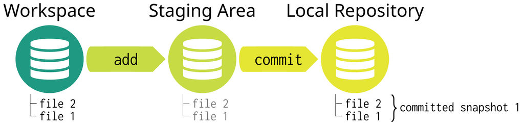

Now if we add another file (`file 3`) to our *workspace*, add this file to the *staging area* and then commit the change, the resulting committed snapshot in the *local repository* will resemble the *workspace*. Note, although the *staging area* contains all three files, only `file 3` points to any new internal content - since `file 1` and `file 2` have unmodified, their instances in the *staging area* point to the same instances as previous. Similarly, the second commit in the *Local repository* will point to one new representation (associated with `file 3`) and two previous representations (associated with `file 1` and `file 2`).

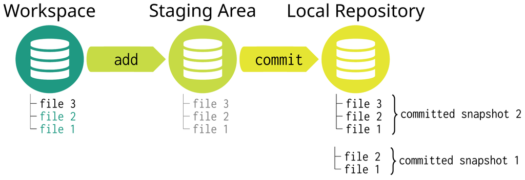

Initially, it might seem that there is an awful lot of duplication going on. For example, if we make a minor alteration to a file, why not just commit the change (delta) instead of an entirely new copy? Well, periodically, git will perform **garbage collection** on the repository. This process **repacks** the objects together into a single object that comprises only the original blobs and their subsequent deltas - thereby gaining efficiency. The process of garbage collection can also be forced at any time via:

```bash
git gc
```

During the evolution of most projects, situations arise in which we wish to start work on new components or features that might represent a substantial deviation from the main line of evolution. Often, we would very much like to be able to quarantine the main thread of the project from these new developments. For example, we may wish to be able to continue tweaking the main project files (in order to address minor issues and bugs), while at the same time, performing major edits that take the project in a different direction.

This is called *branching*. The main evolutionary thread of the project is referred to as the **main** *branch*. Deviations from the *main branch* are generally called **branches** and can be given any name (other than ‘main’ or ‘HEAD’). For example, we could start a new *branch* called ‘Feature’ where we can evolve the project in one direction whilst still being able to actively develop the *main branch* at the same time. ‘Feature’ and ‘main’ *branches* are depicted in the left hand sequence of circles of the schematic below.

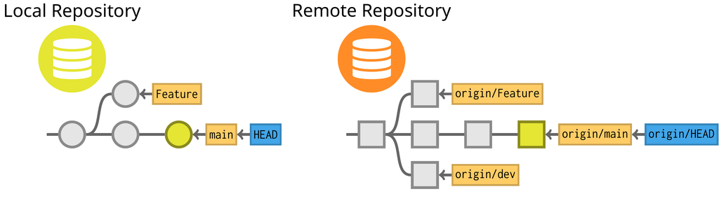

The circles represent **commits** (stored snapshots). We can see that the first commit is the common ancestor of the ‘Feature’ and ‘main’ *branch*. **HEAD** is a special reference that points to the *tip* of the currently active *commit*. It indicates where the next *commit* will be built onto. In diagram above, `HEAD` is pointing to the last *commit* in `main`. Hence the next *commit* will build on this *commit*. To develop the `Feature` *branch* further, we first have to move `HEAD` to the tip of the `Feature` *branch*.

We can later `merge` the `Feature` *branch* into the `main` *branch* in order to make the new changes mainstream.

To support collaboration, there can also be a *remote repository* (referred to as **origin** and depicted by the squares in the figure above). Unlike a *local repository*, a *remote repository* does not contain a *workspace* as files are not directly edited in the *remote repository*. Instead, the *remote repository* acts as a permanently available conduit between multiple contributors.

In the diagram above, we can see that the *remote repository* (`origin`) has an additional *branch* (in this called `dev`). The collaborator whose *local repository* is depicted above has either not yet obtained (**pulled**) this *branch* or has elected not to (as perhaps it is not a direction that they are involved in).

We also see that the `main` *branch* on the *remote repository* has a newer (additional) *commit* than the *local repository*.

Prior to working on *branch* a collaborator should first get any updates to the *remote repository*. This is a two step process. Firstly, the collaborator **fetches** any changes and then secondly **merges** those changes into their version of the *branch*. Collectively, these two actions are called a **pull**.

To make local changes available to others, the collaborator can **push** *commits* up to the *remote repository*. The *pushed* changes are applied directly to the nominated *branch* so it is the users responsibility to ensure as much as possible, their local repository already included the most recent *remote repository* changes (by always *pulling* before *pushing*).

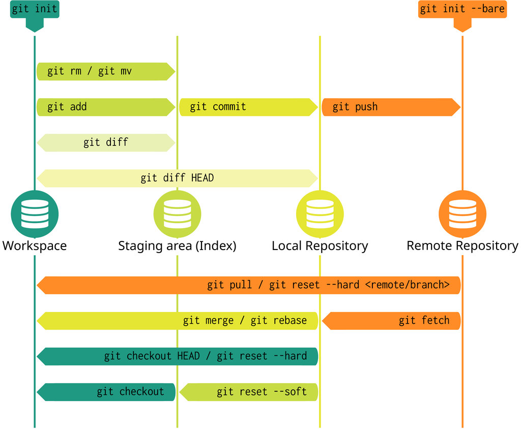

# 3 Installation

**Windows**

Git Bash (Command Line Version):

1. Download the Git for Windows installer from [Git for Windows](https://gitforwindows.org/)
   - Click the Download button
   - Select the latest version from the list of `Assets`
2. Run the installer and follow the installation prompts.
3. Choose the default options unless you have specific preferences.
4. Select the default text editor (usually Vim) or choose another editor like Nano or Notepad++.
5. Choose to use Git from the Windows Command Prompt (recommended).
6. Complete the installation.

**MacOSx**

Using Homebrew:

1. Open Terminal.
2. Install Homebrew if not installed:

```bash
/bin/bash -c "$(curl -fsSL https://raw.githubusercontent.com/Homebrew/install/HEAD/install.sh)"
```

3. Install Git using Homebrew:

```bash
brew install git
```

**Linux**

1. Open Terminal.

Ubuntu/Debian:

```bash
sudo apt update
sudo apt install git
```

Fedora:

```bash
sudo dnf install git
```

Arch Linux:

```bash
sudo pacman -S git
```

Linux (Red Hat/CentOS):

```bash
sudo yum install git
```

To verify that the software is installed and accessible, open a terminal and issue the following:

```bash
git --version
```

```
git version 2.43.0
```

**Unsure how to open a terminal?**

**Windows:**

On Windows, you can access a terminal via one of the following:

- via the command Prompt:
  - Press `Win + R` to open the Run dialog.
  - Type `cmd` and press `Enter`.
- via PowerShell:
  - Press `Win + X` and select “Windows PowerShell.”
- Git Bash (Optional):
  - if Git is installed (which we are hoping it is!), open “Git Bash” for a Unix-like terminal experience.

**MacOS:**

- via Terminal:
  - Press `Cmd + Space` to open Spotlight.
  - Type `terminal` and press `Enter`.

**Linux:**

Oh please. You cannot seriously tell me that you are using Linux and don’t know how to access a terminal.

In the command above, pay particular attention to the number of hyphens in the above command - there are two in a row and no spaces between the `--` and the word `version`.

If you get output similar to above (an indication of what version of git you have on your system), then it is likely to be properly installed. If instead you get an error message, then it is likely that git is not properly installed and you should try again.

# 4 Getting started

Before using git, it is a good idea to define some global (applied to all your gits) settings. These include your name and email address and whilst not essential, they are applied to all actions you perform so the it is easier for others to track the route of changes etc.

```bash
git config --global user.name "Your Name"
git config --global user.email "your_email@whatever.com"
```

**Note**

In the above, you should replace “Your Name” with your actual name. This need not be a username (or even a real name) it is not cross referenced anywhere. It is simply to use in collaboration so that your collaborators know who is responsible for your commits.

Similarly, you should replace “your_email@whatever.com” with an email that you are likely to monitor. This need not be the same email address you have used to register a Github account etc, it is just so that collaborators have a way of contacting you.

The remaining sections go through the major git versioning concepts. As previously indicated, git is a command driven program (technically a family of programs). Nevertheless, many other applications (such as RStudio) are able to interface directly with git for some of the more commonly used features. Hence, in addition to providing the command line syntax for performing each task, where possible, this tutorial will also provide instructions (with screen captures) for RStudio and emacs.

# 5 Setting up (initializing) a new repository

For the purpose of this tutorial, I will create a temporary folder the `tmp` *folder* of my `home` *directory* into which to create and manipulate repositories. To follow along with this tutorial, you are encouraged to do similarly.

## 5.1 Initialize local repository

**Terminal**

We will start by creating a new directory (folder) which we will call `Repo1` in which to place our repository. All usual directory naming rules apply since it is just a regular directory.

```bash
mkdir ~/tmp/Repo1
```

To create (or initialize) a new local repository, issue the `git init` *command* in the root of the working directory you wish to contain the git repository. This can be either an empty directory or contain an existing directory/file structure. The `git init` *command* will add a folder called `.git` to the directory. **This is a one time operation**.

```bash
cd ~/tmp/Repo1
git init
```

```
Initialized empty Git repository in /home/runner/tmp/Repo1/.git/
```

The `.git` *folder* contains all the necessary *metadata* to manage the repository.

```bash
ls -al
```

```
total 12
drwxr-xr-x 3 runner docker 4096 Jan 19 01:05 .
drwxr-xr-x 3 runner docker 4096 Jan 19 01:05 ..
drwxr-xr-x 7 runner docker 4096 Jan 19 01:05 .git
```

```bash
tree -a --charset unicode
```

```
.
`-- .git
    |-- HEAD
    |-- branches
    |-- config
    |-- description
    |-- hooks
    |   |-- applypatch-msg.sample
    |   |-- commit-msg.sample
    |   |-- fsmonitor-watchman.sample
    |   |-- post-update.sample
    |   |-- pre-applypatch.sample
    |   |-- pre-commit.sample
    |   |-- pre-merge-commit.sample
    |   |-- pre-push.sample
    |   |-- pre-rebase.sample
    |   |-- pre-receive.sample
    |   |-- prepare-commit-msg.sample
    |   |-- push-to-checkout.sample
    |   |-- sendemail-validate.sample
    |   `-- update.sample
    |-- info
    |   `-- exclude
    |-- objects
    |   |-- info
    |   `-- pack
    `-- refs
        |-- heads
        `-- tags

10 directories, 18 files
```

**config**

this file stores settings such as the location of a remote repository that this repository is linked to.

**description**

lists the name (and version) of a repository

**HEAD**

lists a reference to the current checked out commit.

**hooks**

a directory containing scripts that are executed at various stages (e.g. `pre-push.sample` is an example of a script executed prior to pushing)

**info**

contains a file `exclude` that lists exclusions (files not to be tracked). This is like `.gitignore`, except is not versioned.

**objects**

this directory contains SHA indexed files being tracked

**refs**

a master copy of all the repository refs

**logs**

contains a history of each branch

**RStudio**

The repository that we are going to create in this demonstration could be considered to be a new standalone analysis. In Rstudio, this would be considered a **project**. So, we will initialise the git repository while we create a new Rstudio project. To do so:

1. click on the `Project` selector in the top right of the Rstudio window (as highlighted by the red ellipse in the image below.

[figure not shown]

2. select `New Project` from the dropdown menu
3. select `New Directory` form the Create Project panel
4. select `New Project` from the Project Type panel
5. Provide a name for the new directory to be created and use the `Browse` button to locate a suitable position for this new directory. **Ensure that the `Create a git repository` checkbox is checked**

[figure not shown]

6. Click the `Create Project` button

If successful, you should notice a couple of changes - these are highlighted in the following figure:

[figure not shown]

- a new `Git` tab will appear in the top right panel
- the contents of this newly created project/repository will appear in the `Files` tab of the bottom right panel

If the files and directories that begin with a `.` do not appear, click on the `More file commands` cog and make sure the `Show Hidden Files` option is ticked.

The newly created files/folders are:

- `.git` - this directory houses the repository information and should not generally be edited directly
- `.gitignore` - this file defines files/folders to be excluded from the repository. We will discuss this file more later
- `.Rhistory` - this file will accrue a history of the commands you have evaluated in R within this project
- `.Rproj.user` - this folder stores some project-specific temporary files
- `Repo1.Rproj` - contains the project specific settings

**Note that on the left side of the Rstudio window there are two panels - one called “Console”, the other called “Terminal”. The console window is for issuing R commands and the terminal window is for issuing system (bash, shell) commands. Throughout this tutorial, as an alternative to using the point and click Rstudio methods, you could instead issue the `Terminal` instructions into the “Terminal” panel. Indeed, there are some git commands that are not supported directly by Rstudio and can only be entered into the terminal**

**Emacs (magit)**

Note, at this stage, no files are being tracked, that is, they are not part of the repository.

To assist in gaining a greater understanding of the workings of git, we will use a series of schematics diagrams representing the contents of four important sections of the repository. Typically, these figures will be contained within callout panels that expand/collapse upon clicking. However, for this first time, they will be standalone.

In the first figure below, the left hand panel represents the contents of the root directory (excluding the `.git` folder) - this is the *workspace* and is currently empty.

The three white panels represent three important parts of the inner structure of the `.git` folder. A newly initialized repository is relatively devoid of any specific metadata since there are no staged or committed files. In the root of the `.git` folder, there is a file called `HEAD`.

The figure is currently very sparse. However, as the repository grows, so the figure will become more complex.

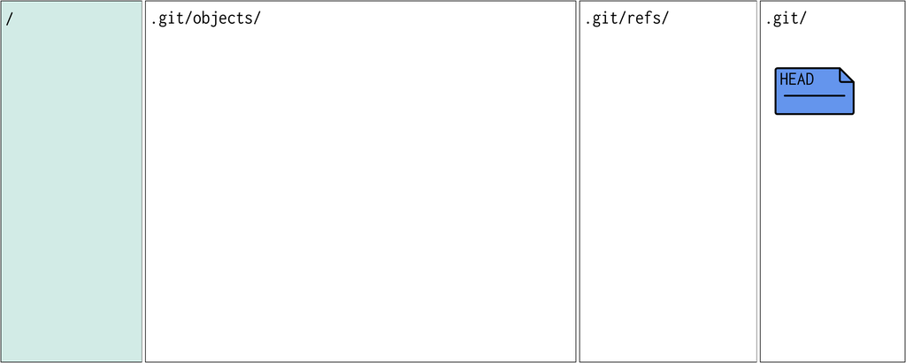

The second figure provides the same information, yet via a network diagram. Again, this will not be overly meaningful until the repository contains some content.

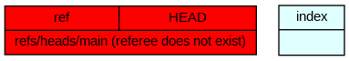

## 5.2 Initializing other types of repositories

The above demonstrated how to initialise a new local repository from scratch. However, there are times when we instead want to:

- create a git repository from an existing directory or project
- collaborate with someone on an existing repository
- create a remote repository

These situations are briefly demonstrated in the following sections.

### 5.2.1 Initializing a shared (remote) repository

The main repository for sharing should not contain the working directory as such - only the `.git` tree and the `.gitignore` file. Typically the point of a remote repository is to act as a perminantly available repository from which multiple uses can exchange files. Consequently, those accessing this repository should only be able to interact with the .git *metadata* - they do not directly modify any files.

Since a remote repository is devode of the working files and directories, it is referred to as *bare*.

**Terminal**

To create a *bare* remote repository, issue the `git init --bare` *command* after logging in to the remote location.

```bash
git init --bare
```

**Rstudio**

Use the instructions for the `Terminal`

### 5.2.2 Cloning an existing repository

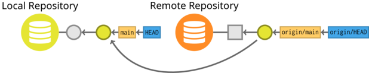

To get your own local copy of an existing repository, issue the `git clone <repo url>` *command* in the root of the working directory you wish to contain the git repository. The `repo url` points to the location of the existing repository to be cloned. This is also a **one time operation** and should be issued in an otherwise empty directory.

The `repo url` can be located on any accessible filesytem (local or remote). The cloning process also stores a link back to the original location of the repository (called **origin**). This provides a convenient way for the system to keep track of where the local repository should exchange files.

Many git repositories are hosted on sites such as github, gitlab or bitbucket. Within an online git repository, these sites provide url links for cloning.

**Terminal**

```bash
git clone "url.git"
```

where `"url.git"` is the url of the hosted repository.

**Rstudio**

### 5.2.3 Initializing a repository in an existing directory

**Terminal**

This is the same as for a new directory.

```bash
git init
```

**Rstudio**

# 6 Tracking files

The basic workflow for tracking files is a two step process in which one or more files are first added to the **staging area** before they are committed to the **local repository**. The staging area acts as a little like a snapshot of what the repository will look like once the changes have been committed. The staging area also acts like a buffer between the files in the workspace (actual local copy of files) and the local repository (committed changes).

The reason that this is a two step process is that it allows the user to make edits to numerous files, yet block the commits in smaller chunks to help isolate changes in case there is a need to roll back to previous versions.

## 6.1 Staging files

When a file is first added to the staging area, a full copy of that file is added to the staging area (not just the file diffs as in other versioning systems).

**Terminal**

To demonstrate lets create a file (a simple text file containing the string saying ‘File 1’) and add it to the staging area.

```bash
echo 'File 1' > file1
```

Now lets add this file to the staging area

```bash
git add file1
```

To see the status of the repository (that is, what files are being tracked), we issue the `git status` *command*

```bash
git status
```

```
On branch main

No commits yet

Changes to be committed:
  (use "git rm --cached <file>..." to unstage)
    new file:   file1
```

This indicates that there is a single file (`file1`) in the staging area

**Rstudio**

To demonstrate lets create a file (a simple text file containing the string saying ‘File 1’) and add it to the staging area.

1. Click the green “New File” button followed by the “Text File” option (or click the equivalent option from the “File” menu)

[figure not shown]

2. Type `File 1` in the panel with the flashing cursor. This panel represents the contents of the yet to be named file that we are creating.

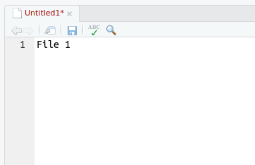

3. Click the “Save” or “Save all” buttons (or select the equivalent items from the “File” menu) and name the file “file1”

   Switch to the `Git` tab and you should notice a number of items (including the file we just created) in the panel. These are files that git is aware of, but not yet tracking. This panel acts as a status window. The yellow “?” symbol indicates that git considers these files “untracked”

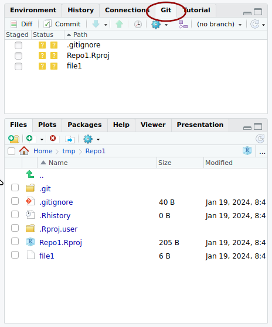

4. To stage a file, click on the corresponding checkbox - the status symbol should change to a green “A” (for added)

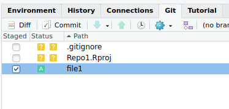

Our simple overview schematic represents the staging of file 1.

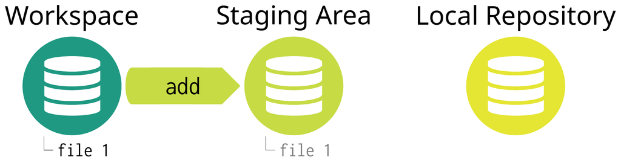

A schematic of the internal working of git shows in `.git/objects` a **blob** has been created. This is a compressed version of `file1`. Its filename is a 40 digit **SHA-1 checksum** has representing the contents of the `file1`. To re-iterate, the blob name is a SHA-1 hash of the file contents (actually, the first two digits form a folder and the remaining 38 form the filename).

We can look at the contents of this *blob* using the `git cat-file` *command*. This command outputs the contents of a compressed *object* (*blob*, *tree*, *commit*) from either the objects name (or unique fraction thereof) or its *tag* (we will discuss tags later).

```bash
git cat-file blob 50fcd
```

```
File 1
```

The add (staging) process also created a `index` file. This file simply points to the *blob* that is part of the snapshot. The git internals schematic illustrates the internal changes in response to staging a file.

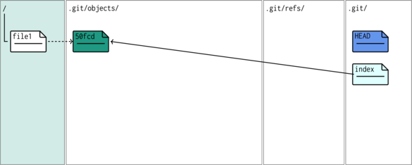

**Another visual representation of the git**

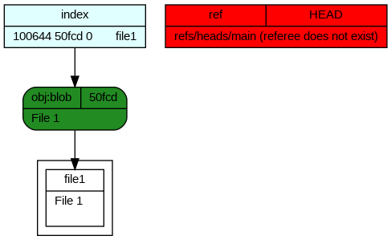

## 6.2 Commit to local repository

**Terminal**

To commit a set of changes from the staging area to the local repository, we issue the `git commit` *command*. We usually add the `-m` *switch* to explicitly supply a message to be associated with the commit. This message should ideally describe what the changes the commit introduces to the repository.

```bash
git commit -m 'Initial repo and added file1'
```

```
[main (root-commit) 1bfaebb] Initial repo and added file1
 1 file changed, 1 insertion(+)
 create mode 100644 file1
```

We now see that the status has changed. It indicates that the tree in the workspace is in sync with the repository.

```bash
git status
```

```
On branch main
nothing to commit, working tree clean
```

**Rstudio**

To commit a set of changes from the staging area to the local repository:

1. click on the “Commit” button to open the “Review Changes” window

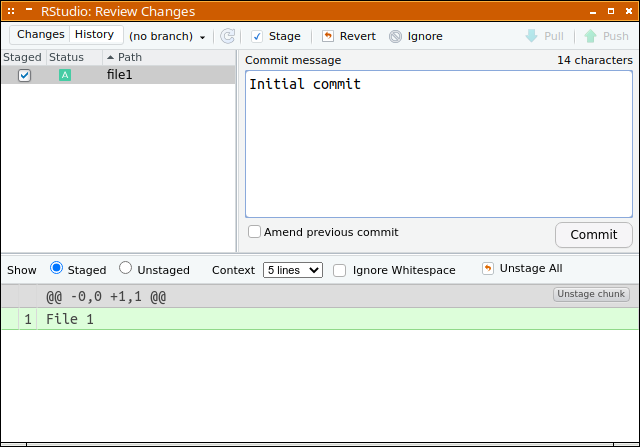

   This box will list the files to be committed (in this case “file1”), the changes in this file since the previous commit (as this is the first time this file has been committed, the changes are the file contents)
2. you should also provide a commit message (in the figure above, I entered “Initial commit”. This message should ideally describe what the changes the commit introduces to the repository.
3. click the “Commit” button and you will be presented with a popup message.

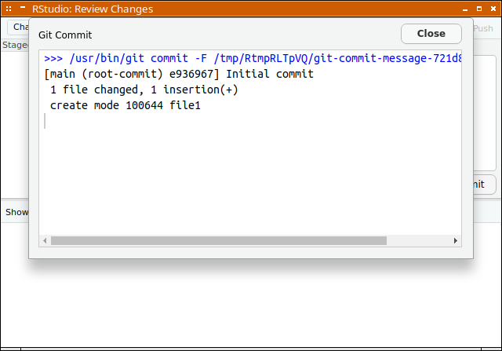

   This message provides feedback to confirm that your commit was successful.
4. close the popup window and the “Review Changes” window

`file1` should now have disappeared from the git status panel.

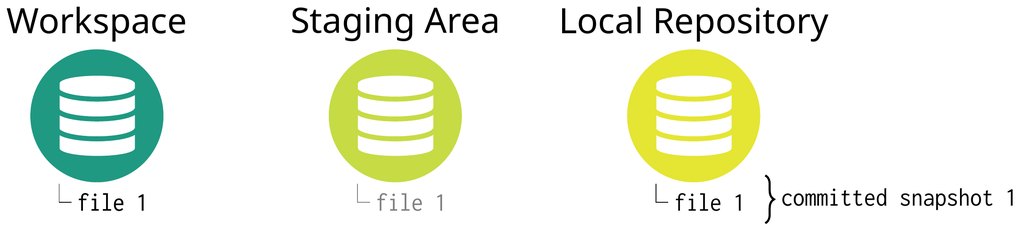

```bash
ls -la
cd .git
ls -la
tree
```

```
total 16
drwxr-xr-x 3 runner docker 4096 Jan 19 01:05 .
drwxr-xr-x 3 runner docker 4096 Jan 19 01:05 ..
drwxr-xr-x 8 runner docker 4096 Jan 19 01:05 .git
-rw-r--r-- 1 runner docker    7 Jan 19 01:05 file1
total 52
drwxr-xr-x 8 runner docker 4096 Jan 19 01:05 .
drwxr-xr-x 3 runner docker 4096 Jan 19 01:05 ..
-rw-r--r-- 1 runner docker   29 Jan 19 01:05 COMMIT_EDITMSG
-rw-r--r-- 1 runner docker   21 Jan 19 01:05 HEAD
drwxr-xr-x 2 runner docker 4096 Jan 19 01:05 branches
-rw-r--r-- 1 runner docker   92 Jan 19 01:05 config
-rwxr-xr-x 1 runner docker   73 Jan 19 01:05 description
drwxr-xr-x 2 runner docker 4096 Jan 19 01:05 hooks
-rw-r--r-- 1 runner docker  137 Jan 19 01:05 index
drwxr-xr-x 2 runner docker 4096 Jan 19 01:05 info
drwxr-xr-x 3 runner docker 4096 Jan 19 01:05 logs
drwxr-xr-x 7 runner docker 4096 Jan 19 01:05 objects
drwxr-xr-x 4 runner docker 4096 Jan 19 01:05 refs
.
├── COMMIT_EDITMSG
├── HEAD
├── branches
├── config
├── description
├── hooks
│   ├── applypatch-msg.sample
│   ├── commit-msg.sample
│   ├── fsmonitor-watchman.sample
│   ├── post-update.sample
│   ├── pre-applypatch.sample
│   ├── pre-commit.sample
│   ├── pre-merge-commit.sample
│   ├── pre-push.sample
│   ├── pre-rebase.sample
│   ├── pre-receive.sample
│   ├── prepare-commit-msg.sample
│   ├── push-to-checkout.sample
│   ├── sendemail-validate.sample
│   └── update.sample
```

[output cut: 8 more lines]

```
├── objects
│   ├── 07
│   │   └── a941b332d756f9a8acc9fdaf58aab5c7a43f64
│   ├── 1b
│   │   └── faebb02379ea936395f8b02fd34c4ced4bb6f3
│   ├── 50
│   │   └── fcd26d6ce3000f9d5f12904e80eccdc5685dd1
│   ├── info
│   └── pack
└── refs
    ├── heads
    │   └── main
    └── tags

15 directories, 26 files
```

**Additional details about the commit**

The following modifications have occurred (in reverse order to how they actually occur):

- The **main** *branch* reference was created. There is currently only a single branch (more on branches later). The branch reference point to (indicates) which commit is the current commit within a branch.

  ```bash
  cat .git/refs/heads/main
  ```

  ```
  1bfaebb02379ea936395f8b02fd34c4ced4bb6f3
  ```

- A **commit** was created. This points to a **tree** (which itself points to the blob representing `file1`) as well as other important metadata (such as who made the commit and when). Since the time stamp will be unique each time a snapshot is commited, so too the name of the commit (as a SHA-1 checksum hash) will differ. **To reiterate, the names of blobs and trees are determined by contents alone, commit names are also incorporate commit timestamp and details of the committer - and are thus virtually unique**.

  ```
  git cat-file commit 1bfae
  ```

  ```
  tree 07a941b332d756f9a8acc9fdaf58aab5c7a43f64
  author pcinereus <i.obesulus@gmail.com> 1705626323 +0000
  committer pcinereus <i.obesulus@gmail.com> 1705626323 +0000

  Initial repo and added file1
  ```

- A **tree** object was created. This represents the directory tree of the snapshot (commit) and thus points to the **blob**s.

  ```
  git ls-tree 1bfae
  ```

  ```
  100644 blob 50fcd26d6ce3000f9d5f12904e80eccdc5685dd1  file1
  ```

  Or most commonly (if interested in the latest commit):

  ```
  git ls-tree HEAD
  ```

  ```
  100644 blob 50fcd26d6ce3000f9d5f12904e80eccdc5685dd1  file1
  ```